# Introducing our dataset

The Met Office makes available historical weather data for 25+ sites from 1870 onwards at this website: http://www.metoffice.gov.uk/public/weather/climate-historic/#?tab=climateHistoric

Data looks as follows:

```
## # A tibble: 2 x 8
##    yyyy    mm  tmax  tmin    af  rain sun   location
##   <dbl> <dbl> <dbl> <dbl> <dbl> <dbl> <lgl> <chr>
## 1  1873     7  16.7   9.9     0  110. NA    stornoway
## 2  1873     8  15.5   8.9     0  141  NA    stornoway
```

There’s data for at least 50 years for a total of 25 different locations through the United Kingdom.

It’s somewhat interesting to pose the following question of the data:

> What’s the average temperature difference between the maximal and minimal temperature recorded in each month, for each location?

Let’s compare three different approaches to presenting this data:

- Tables
- Static `ggplot` chart
- Interactive chart and map of points

# Tables Only

Data was collected from 25 different locations in the United Kingdom, labelled according to region (England, Northern Ireland, Scotland, Wales), from 1873 to today using the Met Offices climatic history explorer. Mean temperature ranges per month were calculated for each region

| region | Jan | Feb | Mar | Apr | May | Jun | Jul | Aug | Sep | Oct | Nov | Dec |
| --- | --- | --- | --- | --- | --- | --- | --- | --- | --- | --- | --- | --- |
| England | 5.5 | 5.9 | 7.2 | 8.3 | 8.8 | 9.0 | 8.9 | 8.8 | 8.2 | 7.0 | 6.0 | 5.5 |
| Northern Island | 5.3 | 5.8 | 6.9 | 8.0 | 8.5 | 8.4 | 7.8 | 7.7 | 7.2 | 6.4 | 5.8 | 5.2 |
| Scotland | 5.0 | 5.4 | 6.0 | 6.9 | 7.3 | 7.0 | 6.7 | 6.6 | 6.3 | 5.8 | 5.4 | 5.1 |
| Wales | 4.9 | 5.2 | 5.9 | 6.7 | 7.0 | 6.9 | 6.7 | 6.5 | 6.3 | 5.6 | 5.1 | 4.8 |

# Static `ggplot` chart

Data was collected from 25 different locations in the United Kingdom, labelled according to region (England, Northern Ireland, Scotland, Wales), from 1873 to today using the Met Offices climatic history explorer. Mean temperature ranges per month were calculated for each region.

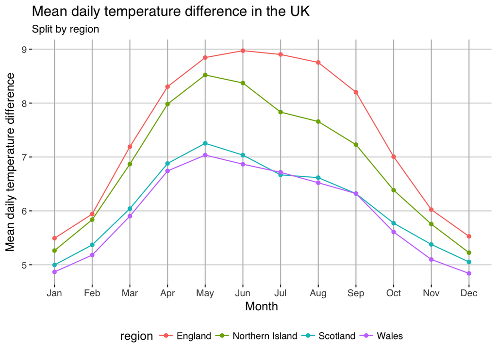

# Interactive chart and map of points

Data was collected from 25 different locations in the United Kingdom, labelled according to region (England, Northern Ireland, Scotland, Wales), from 1873 to today using the Met Offices climatic history explorer.

[interactive chart not shown]

[interactive chart not shown]